# 3 Liste i petlje

## 3.1 Podsetnik

- Problemi sa domacim?
- Pogledati **2_python_sintaksa_kontrola_toka.ipynb**

## 3.2 Liste

- Liste se koriste za smestanje niza elemenata u jednu promenljivu
- Lista je jedan od cetiri ugradjena kontejner tipa u Python-u - tipova koji sluze da drze kolekcije nekih elemenata (postoje jos tuple, set i dictionary)
- **list** je rezervisana rec!

```python
ucenici = ["Pera", "Zika", "Mika"]  # 'ucenici' je lista - kolekcija tri stringa

print(ucenici)
print(f"U ovoj listi ima {len(ucenici)} elementa")
print(type(ucenici))
```

```
['Pera', 'Zika', 'Mika']
U ovoj listi ima 3 elementa
<class 'list'>
```

- Funkcija **len(lista)** vraca broj elemenata u listi
- Elementi u listi su uredjeni, promenljivi i dozvoljeni su duplikati
- Lista moze sadrzati elemente bilo kog tipa, ne samo primitivne tipove
- Moze sadrzati i elemente raznih tipova, ali to je pametnije ne koristiti i retko kad zaista ima potrebe za tim u praksi

```python
lista_intova = [1, 3, 6, 3, 7, 2, 9, 300]

lista_boolova = [True, False, False, True]

mix_lista = ["string", False, 5, 666.666]   # Ne koristiti
```

## 3.3 Indeksiranje

- Nacin na koji pristupamo elementima liste je koriscenjem indeksa
- Indeksi u Python-u pocinju od 0
- Ovo je uradjeno iz pozadinskih implementacionih razloga brze aritmetike sa memorijskim lokacijama

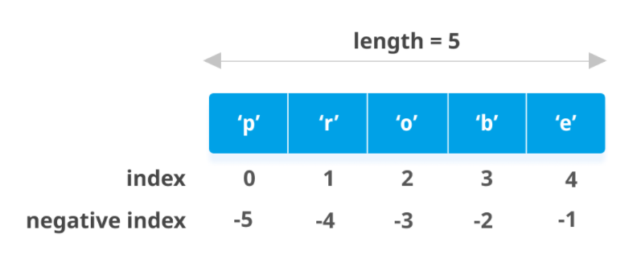

```python
lista = ['p', 'r', 'o', 'b', 'e']

print(lista)
print(lista[0])
print(lista[4])
print(lista[-3])    # Negativni indeksi znace da brojimo zdesna na levo
print(lista[5])     # Aha, izasli smo iz opsega liste
```

```
['p', 'r', 'o', 'b', 'e']
p
e
o
```

```
---------------------------------------------------------------------------
IndexError                                Traceback (most recent call last)
<ipython-input-9-e439d3f3ac98> in <module>()
      5 print(lista[4])
      6 print(lista[-3])    # Negativni indeksi znace da brojimo zdesna na levo
----> 7 print(lista[5])     # Aha, izasli smo iz opsega liste

IndexError: list index out of range
```

```python
prazna_lista = []

print(prazna_lista)
print(len(prazna_lista))
```

```
[]
0
```

- Moguce je indeksirati listu i tako da se uzima svaki n-ti element

```python
lista = [1, 2, 3, 4, 5, 6]

# Ovakvo indeksiranje ide od pocetka do kraja
cela_lista = lista[:]

# Ovakvo indeksiranje uzima svaki drugi clan liste
svaki_drugi = lista[::2]

# Moze i od nazad
unazad = lista[::-1]

print(lista)
print(cela_lista)
print(svaki_drugi)
print(unazad)
```

```
[1, 2, 3, 4, 5, 6]
[1, 2, 3, 4, 5, 6]
[1, 3, 5]
[6, 5, 4, 3, 2, 1]
```

## 3.4 Slajsovanje

- Cesto je potrebno iz liste izvuci vise podataka odjednom i njih smestiti u zasebnu listu
- Ovo se radi koriscenjem slicing-a

```python
meseci = ["Jan", "Feb", "Mar", "Apr", "Maj", "Jun", "Jul", "Avg", "Sep", "Okt", "Nov", "Dec"]

prva_tri_meseca = meseci[0:3]   # Primetite desnu granicu slajsovanja
print(prva_tri_meseca)

poslednji_mesec_u_godini = meseci[-1]
print(poslednji_mesec_u_godini)
```

```
['Jan', 'Feb', 'Mar']
Dec
```

- Kada se radi slajsovanje, desna granica nije ukljucena! (ovo je kao u matematici poluotvoren skup [prvi, poslednji) )

## 3.5 Append

- U listu koja je vec formirana moze se dodati novi element koriscenjem funkcije **append**
- Ovo je zgodno kad nije unapred poznat broj elemenata koji ce se pojaviti za obradu, vec kako koji pristize, tako se pakuje u listu

```python
lista = [3, 2, 9, 8]

print(lista)

# Dodaj 5 na kraj liste
lista.append(5)

print(lista)
```

```
[3, 2, 9, 8]
[3, 2, 9, 8, 5]
```

### Zadatak

1. Napraviti listu dana u nedelji. Indeksiranjem izdvojiti prvi, cetvrti i sedmi dan i ispisati ih. Slajsovanjem izdvojiti radnu sedmicu i ispisati dane u njoj. Na standardni izlaz ispisati koliko lista ima elemenata i kog su tipa elementi u njoj.

## 3.6 For petlja

- **Petlje** (loops) sluze za iterativno ponavljanje bloka instrukcija
- Naredbe koje iniciraju petlje takodje se smatraju kontrolom toka programa poput if i else naredbi
- U Python-u dva tipa petlji: for i while
- For se najcesce koristi za iteriranje po odredjenoj unapred poznatoj sekvenci, a while za iteriranje sve dok se ne ispuni neki uslov

```python
elementi = [1, 2, 3, 4, 5]

for element in elementi:
    print(element)
```

```
1
2
3
4
5
```

- Cesto se koristi **range** da se generise neki niz kroz koji se iterira

```python
for i in range(1, 6):     # Slicno, desna granica nije ukljucena
    print(i)
```

```
1
2
3
4
5
```

- Jos jedna korisna funkcija je **enumerate**

```python
likovi = ["Raja", "Gaja", "Vlaja"]

for index, lik in enumerate(likovi):
    print(index, lik)
```

```
0 Raja
1 Gaja
2 Vlaja
```

### Zadatak

1. Napisati program koji koriscenjem for petlje na ekran 5 puta ispisuje recenicu "Danas smo ucili liste i petlje"

## 3.7 While petlja

- While petlja vrsi iteracije kroz blok komandi sve dok je neki usput ispunjen
- Cesta pocetnicka greska: beskonacne petlje

```python
i = 0

while i < 10:
    print(i)
    i += 1
```

```
0
1
2
3
4
5
6
7
8
9
```

```python
# Ovo bi se zaglavilo i vecito bi ispisivalo isto dok ne ubijemo interpreter
while 1 < 2:
   print("Infinity")
```

## 3.8 Continue i break

- Naredbe koje sluze da se iteracija preskoci ili da se prekine prevremeno

```python
for i in range(1, 11):
    if i == 5 or i == 4:
        continue
    elif i == 7:
        break
    else:
        print(i)
```

```
1
2
3
6
```

## 3.9 Domaci

**Napomena**: probajte kastovanje nekog stringa u listu pre nego krenete da radite zadatke, trebace vam.

1. Napisati program koji ucitava ceo broj n i potom n puta ispisuje recenicu "Hello, world!" na ekran. Prijaviti gresku ukoliko n nije pozitivan i ceo broj.
2. Napisati program koji ucitava nenegativan ceo broj n, a potom ispisuje sve cele brojeve od 0 do n. U slucaju neispravnog unosa prijaviti info o gresci.
3. Napisati program koji ucitava dva cela broja n i m (n <= m) i ispisuje sve cele brojeve iz intervala [n, m]. U slucaju neispravnog unosa prijaviti info o gresci. Zadatak resiti koriscenjem
   > - For petlje
   > - While petlje
4. Napisati program koji za ucitan nenegativan ceo broj n racuna i ispisuje njegov faktorjel. https://en.wikipedia.org/wiki/Factorial
5. Napisati program koji za ucitan nenegativan ceo broj n racuna i ispisuje njegov dvostruki faktorjel. https://en.wikipedia.org/wiki/Double_factorial
6. Napisati program koji ucitava realan broj x i ceo nenegativan broj n i izracunava n-ti stepen broja x. U slucaju neispravnog unosa ispisati odgovarajucu poruku o gresci. Zadatak resiti bez koriscenja aritmetickog operatora **

```
# Primer

Unesite x i n:
================
3.14 5
================
# Rezultat
"3.14^5 je 305.2447761"
```

1. Pravi delioci celog broja su svi delioci osim jedinice i samog tog broja. Napisati program koji za uneti pozitivan ceo broj n ispisuje sve njegove prave delioce. U slucaju neispravnog unosa ispisati odgovarajucu poruku o gresci.
2. Napisati program koji za uneti ceo broj ispisuje broj dobijen uklanjanjem svih zavrsnih nula unetog broja.

```
# Primer

Unesi broj:
=============
204801000
=============
# Rezultat
204801
```

1. Napisati program koji ucitava ceo broj i ispisuje njegove cifre u obrnutom poretku, i to prvo parne, pa zatim neparne.

```
# Primer

Unesi broj:
==============
832671
==============
# Rezultat
6 2 8
1 7 3
```

1. Napisati program koji za uneti pozitivan ceo broj ispisuje da li je on deljiv sumom svojih cifara. U slucaju neispravnog unosa, ispisati odgovarajucu poruku o gresci.
2. Knjigovodja vodi evidenciju o transakcijama jedne firme i treba da napise izvestaj o godisnjem poslovanju te firme. Firma je tokom godine imala t transakcija. Transakcije su predstavljene celim brojevima i u slucaju da je vrednost transakcije pozitivna, ta transakcija oznacava prihod firme, a u slucaju da je negativna - rashod. Napisati program koji ucitava ceo broj t i podatke o t transakcija (tj. njihove novcane vrednosti) i zatim izracunava i ispisuje ukupan prihod, rashod i zaradu, odnosno gubitak koji je firma ostvarila tokom godine. U slucaju neispravnog unosa ispisati odgovarajucu poruku o gresci.

```
# Primer

Unesite broj transakcija:
========================
5
========================
Unesite transakcije:
100 200 -300 1000 -100
========================
# Rezultat
Prihod: 1300
Rashod: 400
Zarada: 900
```

1. Napisati program koji ucitava pozitivan ceo broj n, a potom i n celih brojeva. Izracunati i ispisati zbir onih brojeva koji su istovremeno neparni i negativni. U slucaju neispravnog unosa ispisati odgovarajucu poruku o gresci.
2. Napisati program koji ucitava cele brojeve sve dok se ne unese broj 0 i ispisuje proizvod onih unetih brojeva koji su pozitivni.

```
# Primer

Unesite brojeve:
=================
2 -3 5 -1 0
=================
# Rezultat
10
```

1. Napisati program koji za uneti ceo broj proverava i ispisuje da li se cifra 5 nalazi u njegovom zapisu.
2. Napisati program koji ucitava cele brojeve sve do unosa broja 0, a zatim izracunava i ispisuje aritmeticku i geometrijsku sredinu unetih brojeva na cetiri decimale.